# Determining The Best City to Live In as a Post-Grad

Cece Haase and Gabby Reese

[Link to our GitHub website](https://github.com/gabbyreese/gabbyreese.github.io/)

# Project Goals

The goal of this project is to investigate and determine the best city to live in as a post-grad in terms of walkability, diversity, population average age, average income, and weather. We will be investigating 10 popular cities.

# Project Dataset

One of the datasets we are considering working with is [The Walkability Index](https://catalog.data.gov/dataset/walkability-index1). This data is provided by the U.S. Environmental Protection Agency. The Walkability Index dataset characterizes every Census 2019 block group in the U.S. based on its relative walkability. Walkability depends upon characteristics of the built environment that influence the likelihood of walking being used as a mode of travel.

Within our project we will likely use two to three datasets. We have determined that the factors we will focus on when analysing the livability of a city is its walkability, diversity, population average age, average income, and weather. For each factor, we will take the average index of each city and compile these factors together in a data table. By examining these factors, we hope to create a resource for post graduates looking to make an informed decision on where they should move to. Our data table and graphs using this data we have collected will help display what each of these cities have to offer. We will be assessing Atlanta, Austin, Boston, Chicago, Denver, Los Angeles, Miami, New York City, Philadelphia, and Washington DC.

# Collaboration Plan

Our collaboration plan is to meet on zoom once a week to work on the final project. We have set up a google colab to work on our code together and make any updates. From now to April 12, we plan on finalizing the datasets we are using, cleaning and tidying up our data and creating necessary graphs for Milestone 2. From April 12 to May 3, we plan on developing our insights, visualizations, and presentation for the final project and presentation.

# ETL (Extraction, Transform, and Load)

```python
import numpy as np
import matplotlib.pyplot as plt
import pandas as pd
```

```python
df = pd.read_csv('../EPA_SmartLocationDatabase_V3_Jan_2021_Final.csv')
```

[output not shown]

220740 rows × 117 columns

Distributions

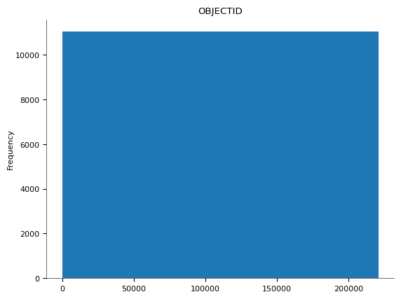

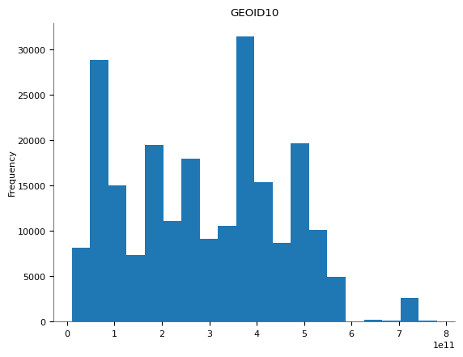

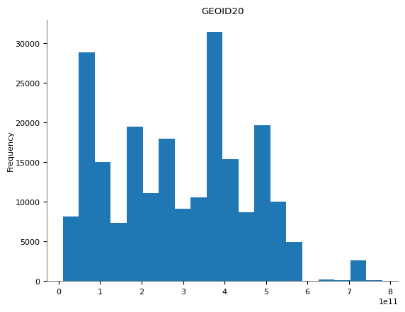

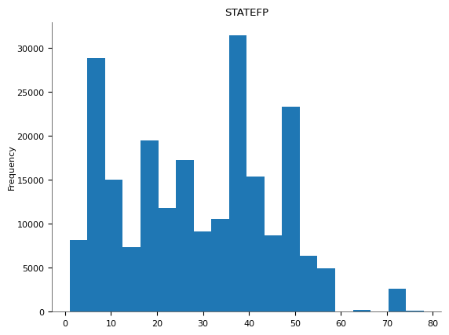

2-d distributions

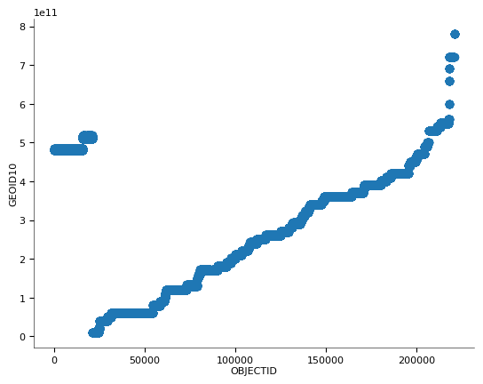

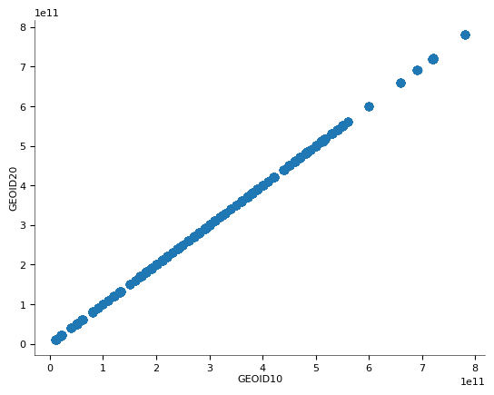

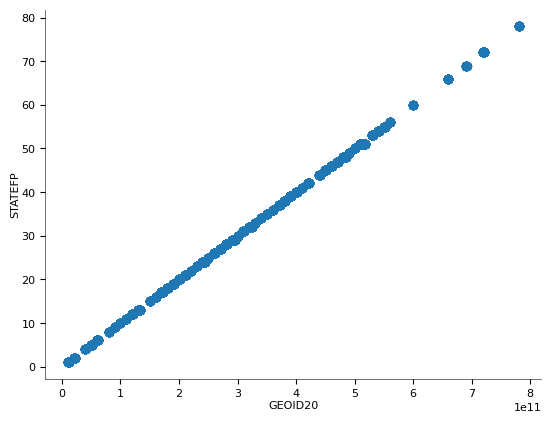

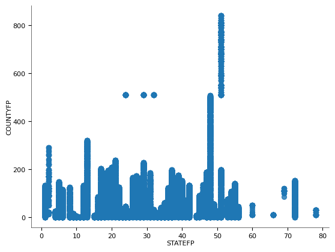

Time series

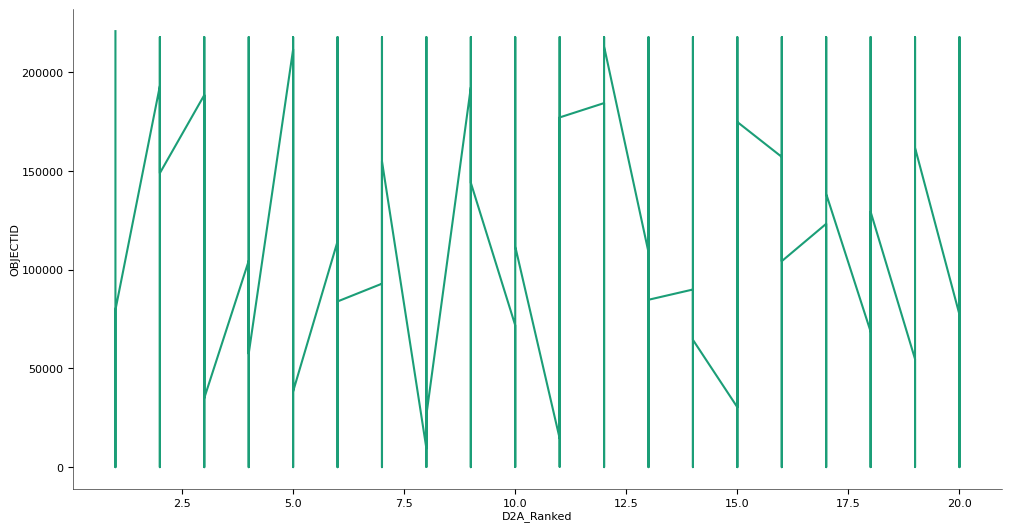

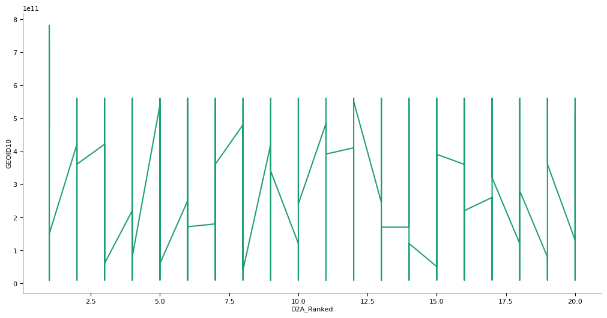

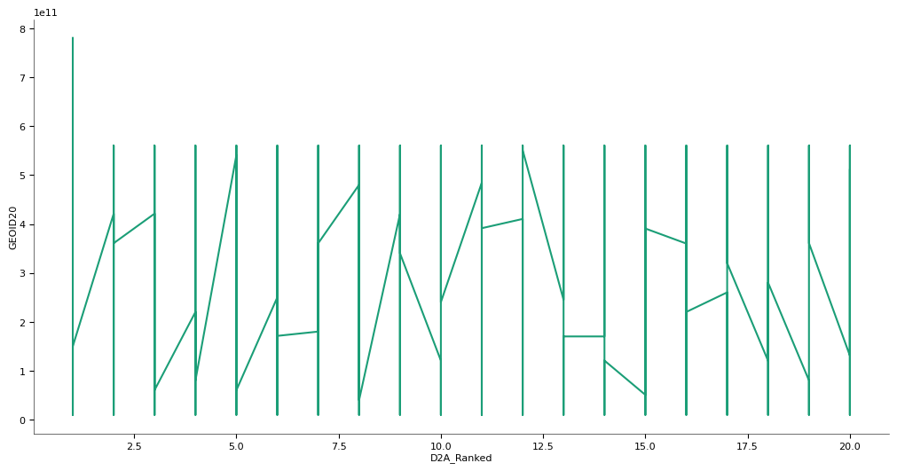

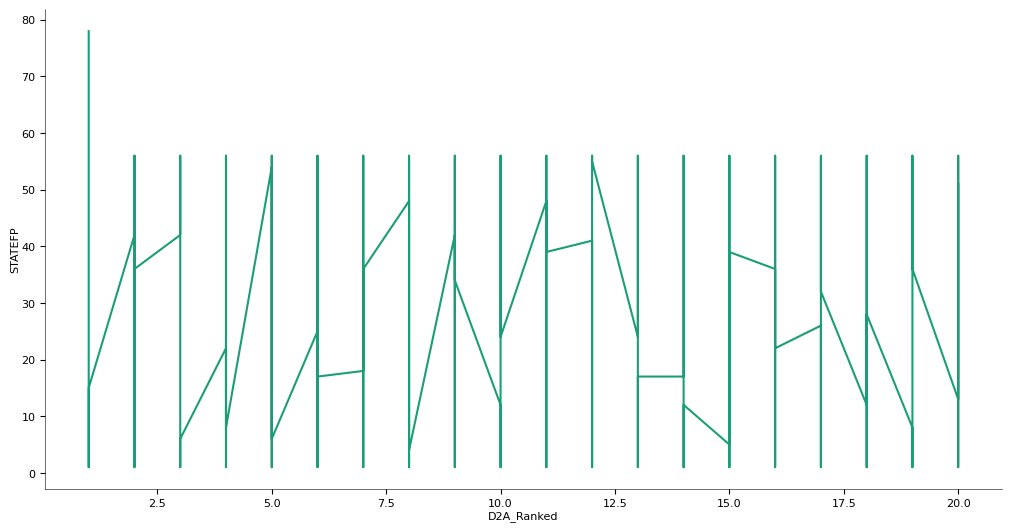

Values

[2 more figures not shown]

```python
df.sort_values(by=["D2A_Ranked"])
```

```python
f_df = pd.melt(df,
               id_vars=["GEOID10", "NatWalkInd"],
               var_name="CSA_Name",
               value_name="D2A_Ranked")


f_df.head()
```

|  | GEOID10 | NatWalkInd | CSA_Name | D2A_Ranked |
| --- | --- | --- | --- | --- |
| 0 | 4.811300e+11 | 14.000000 | OBJECTID | 1 |
| 1 | 4.811300e+11 | 10.833333 | OBJECTID | 2 |
| 2 | 4.811300e+11 | 8.333333 | OBJECTID | 3 |
| 3 | 4.811300e+11 | 15.666667 | OBJECTID | 4 |
| 4 | 4.811300e+11 | 10.166667 | OBJECTID | 5 |

```python
from google.colab import drive
drive.mount('/content/drive')
```

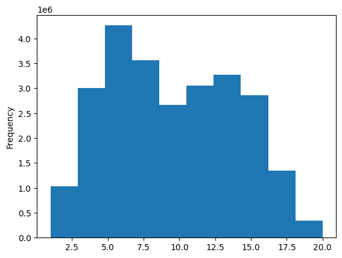

```python
f_df.NatWalkInd.plot.hist() #shows frequency of national walking index scores, helpful use for comparrison across cities
```

```python
%%shell
jupyter nbconvert --to html '/content/drive/MyDrive/Other/Data Science Final Project'
```

[output not shown]

[output not shown]